# Joint Headline HICP — 4-component Bayesian VAR with SV and model-based outliers

This is the current **production Headline model**.

The model is intentionally simple and joint:

[ y_t = \begin{pmatrix} \Delta\log HICP^{Energy}_t\\ \Delta\log HICP^{Food}_t\\ \Delta\log HICP^{NEIG}_t\\ \Delta\log HICP^{Services}_t \end{pmatrix}. ]

All four components are endogenous in one monthly BVAR. This removes the need to pair posterior draws from separately estimated component models and gives a single joint posterior distribution for the four Headline blocks.

The detailed WP374 component models are **deferred decomposition models** and live under `notebooks/decomposition/`. They are not required to run this notebook.

### Production choices

- canonical model: **dense BVAR(12)**;
- only lag sensitivity: **dense BVAR(6)**;
- no sparse-lag restriction in the joint model (`active_lags=None`);
- same validated Energy-suite Bayesian machinery:
  - Minnesota shrinkage;
  - stochastic volatility;
  - model-based outliers;
  - Durbin–Koopman ragged-edge treatment;
  - shared registry/diagnostics.

The four model inputs are aggregate HICP indices. Therefore every variable uses the same transformation:

[ HICP_t \rightarrow \log(HICP_t) \rightarrow \Delta\log(HICP_t). ]

The Food aggregate is read from Haver ticker `H023HA1@EUDATA`. Annual Food aggregation weights are constructed upstream as Processed Food + Unprocessed Food official HICP weights.

## 1. Imports and configuration

```python
from __future__ import annotations

import os
import sys
from dataclasses import asdict
from pathlib import Path

import numpy as np
import pandas as pd
import matplotlib.pyplot as plt
from IPython.display import display


def find_project_root(start: Path) -> Path:
    start = start.resolve()
    for candidate in (start, *start.parents):
        if (candidate / "data").exists() and (candidate / "src").exists():
            return candidate
    raise FileNotFoundError("Could not locate project root containing data/ and src/.")


env_root = os.environ.get("BVAR_PROJECT_ROOT")
PROJECT_ROOT = (
    Path(env_root).expanduser().resolve()
    if env_root
    else find_project_root(Path.cwd())
)

MODEL_DIR = PROJECT_ROOT / "src" / "model"
if str(MODEL_DIR) not in sys.path:
    sys.path.insert(0, str(MODEL_DIR))

from headline_joint_bvar import (
    BASELINE_P,
    SENSITIVITY_P,
    NATIVE_VARIABLES,
    BVARSVOPriorConfig,
    SamplerConfig,
    aggregate_headline_draws,
    forecast_headline_joint_bvar,
    headline_component_forecast_table,
    headline_forecast_table,
    headline_joint_panel_audit,
    headline_joint_spec,
    headline_reconstruction_diagnostics,
    lag_comparison_table,
    load_headline_joint_panel,
    load_headline_joint_weights,
    load_official_headline_total,
    native_to_state_levels,
    resolve_headline_reconstruction_start_year,
    reconstruct_headline_history,
    resolve_headline_joint_dataset,
    resolve_headline_joint_weights,
    resolve_headline_official_indices,
    run_headline_joint_bvar,
)

from headline_joint_plot import (
    plot_headline_aggregate_forecast,
    plot_headline_historical_reconstruction,
    plot_joint_component_forecast_fans,
    plot_joint_model_changes,
    plot_joint_native_levels,
)

from energy_bvar_model import (
    coefficient_posterior_table,
    mcmc_diagnostics,
    posterior_predictive_statistics,
    residual_diagnostic_table,
    stability_diagnostics,
    stationarity_tests,
)

from energy_bvar_plot import (
    plot_chain_acf_grid,
    plot_coefficient_heatmap,
    plot_outlier_probabilities,
    plot_phi_and_outlier_priors,
    plot_posterior_predictive_check,
    plot_posterior_volatility,
    plot_spectral_radius,
    plot_standardized_residuals,
    plot_trace_grid,
    style_numeric_table,
)

try:
    from energy_bvar_io import save_energy_bvar_result
except ImportError:
    save_energy_bvar_result = None


SPEC = headline_joint_spec()

DATA_ROOT = None
VINTAGE = None

QUICK_TEST = False
FORECAST_HORIZON = 18
FORECAST_DRAWS = 250 if QUICK_TEST else 1_000
SAVE_RESULTS = False

# The only lag sensitivity allowed in the current methodology is BVAR(6) vs BVAR(12).
RUN_BVAR6_SENSITIVITY = False

PRIOR_CONFIG = BVARSVOPriorConfig(
    lambda1=0.20,
    lambda2=0.50,
    lambda3=1.00,
    lambda4=10.0,
    a_prior_var=10.0,
    phi_prior_mean=0.02,
    phi_prior_df=10.0,
    h0_var=4.0,
    outlier_mean_frequency=1.0 / 48.0,
    outlier_prior_observations=120.0,
    outlier_grid_min=2.0,
    outlier_grid_max=20.0,
    outlier_grid_step=1.0,
    ksc_offset_scale=1e-6,
)

SAMPLER_CONFIG = SamplerConfig(
    reps=300 if QUICK_TEST else 6_000,
    burn=150 if QUICK_TEST else 3_000,
    thin=1,
    seed=42,
    max_stability_tries=1_000,
    progress_every=0 if QUICK_TEST else 500,
)

print("PROJECT_ROOT:", PROJECT_ROOT)
print("Canonical model:", f"dense BVAR({BASELINE_P})")
print("Only lag sensitivity:", f"dense BVAR({SENSITIVITY_P})")
print("Variable ordering:", NATIVE_VARIABLES)
```

```
PROJECT_ROOT: C:\Users\kelyan.gane\Project\Python\Bayesian_model\bvar-energy
Canonical model: dense BVAR(12)
Only lag sensitivity: dense BVAR(6)
Variable ordering: ['hicp_energy', 'hicp_food', 'hicp_neig', 'hicp_services']
```

### Variable ordering

The canonical order is fixed as:

```
1. HICP Energy
2. HICP Food
3. HICP NEIG
4. HICP Services
```

The BVAR forecast itself is the primary object. Any future recursive structural interpretation must explicitly acknowledge this ordering; this notebook does **not** label the recursive innovations as economic structural shocks.

## 2. Resolve the official processed vintage

```python
DATASET_PATH = resolve_headline_joint_dataset(
    PROJECT_ROOT,
    vintage=VINTAGE,
    data_root=DATA_ROOT,
)
VINTAGE_USED = DATASET_PATH.parent.name

WEIGHTS_PATH = resolve_headline_joint_weights(
    PROJECT_ROOT,
    vintage=VINTAGE_USED,
    data_root=DATA_ROOT,
)
OFFICIAL_INDICES_PATH = resolve_headline_official_indices(
    PROJECT_ROOT,
    vintage=VINTAGE_USED,
    data_root=DATA_ROOT,
)

print("Vintage:", VINTAGE_USED)
print("Joint dataset:", DATASET_PATH)
print("Annual weights:", WEIGHTS_PATH)
print("Official total/reference indices:", OFFICIAL_INDICES_PATH)
```

```
Vintage: 20260811_headline_joint
Joint dataset: C:\Users\kelyan.gane\Project\Python\Bayesian_model\bvar-energy\data\processed\20260811_headline_joint\headline_joint_monthly.csv
Annual weights: C:\Users\kelyan.gane\Project\Python\Bayesian_model\bvar-energy\data\processed\20260811_headline_joint\headline_joint_weights_annual.csv
Official total/reference indices: C:\Users\kelyan.gane\Project\Python\Bayesian_model\bvar-energy\data\processed\20260811_headline_joint\headline_hicp_indices_monthly.csv
```

## 3. Load and audit native HICP inputs

```python
native_levels = load_headline_joint_panel(DATASET_PATH)
weights = load_headline_joint_weights(WEIGHTS_PATH)
official_total = load_official_headline_total(OFFICIAL_INDICES_PATH)

display(headline_joint_panel_audit(native_levels))

complete_weights = weights.dropna(how="any")
weight_check = pd.DataFrame(
    {
        "component_sum": complete_weights.sum(axis=1),
        "sum_minus_1000": complete_weights.sum(axis=1) - 1000.0,
    }
)
display(weight_check.tail(10))
```

| series | first_observed | last_observed | observations | leading_missing | interior_missing | trailing_missing | min | max |
| --- | --- | --- | --- | --- | --- | --- | --- | --- |
| hicp_energy | 1996-01-01 | 2026-07-01 | 367 | 12 | 0 | 0 | 35.84 | 117.62 |
| hicp_food | 1995-01-01 | 2026-06-01 | 378 | 0 | 0 | 1 | 48.63 | 101.43 |
| hicp_neig | 1999-12-01 | 2026-07-01 | 320 | 59 | 0 | 0 | 78.22 | 101.78 |
| hicp_services | 1999-12-01 | 2026-07-01 | 320 | 59 | 0 | 0 | 57.68 | 104.81 |

| year | component_sum | sum_minus_1000 |
| --- | --- | --- |
| 2017 | 1000.00 | 0.00 |
| 2018 | 1000.00 | 0.00 |
| 2019 | 1000.01 | 0.01 |
| 2020 | 999.99 | -0.01 |
| 2021 | 1000.00 | 0.00 |
| 2022 | 1000.00 | 0.00 |
| 2023 | 1000.00 | 0.00 |
| 2024 | 1000.01 | 0.01 |
| 2025 | 1000.00 | 0.00 |
| 2026 | 1000.00 | 0.00 |

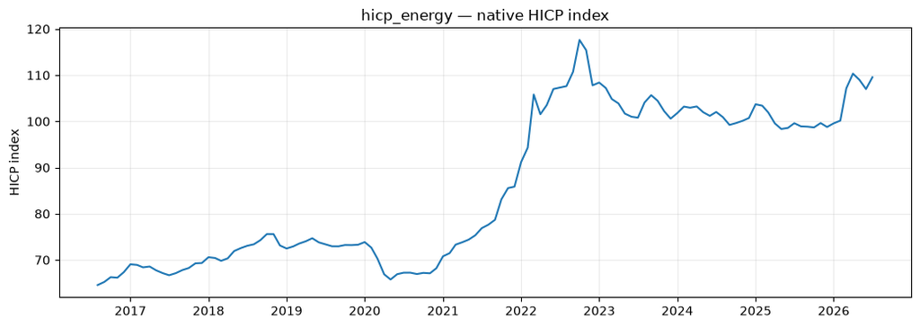

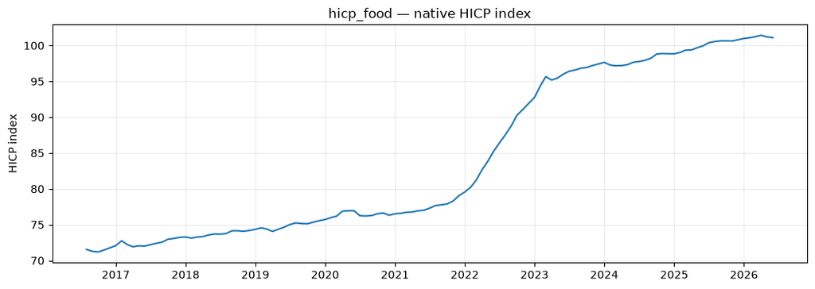

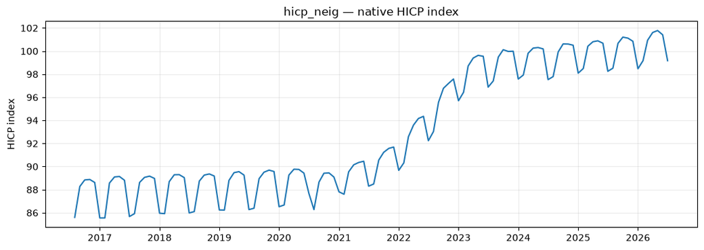

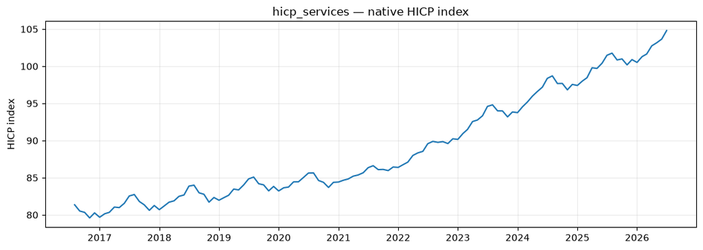

```python
figures = plot_joint_native_levels(native_levels, last_obs=120)
for fig in figures.values():
    display(fig)
    plt.close(fig)
```

The builder keeps all four variables in **native index levels**. No log transformation or differencing is hidden in the Excel/data-construction layer.

## 4. Common model-space transformation

|  | count | mean | std | min | 25% | 50% | 75% | max |
| --- | --- | --- | --- | --- | --- | --- | --- | --- |
| state__hicp_energy | 366.0 | 0.302774 | 1.720969 | -6.830612 | -0.550377 | 0.261077 | 1.126826 | 11.496329 |
| state__hicp_food | 377.0 | 0.194130 | 0.360903 | -0.913844 | -0.014289 | 0.163132 | 0.327204 | 1.782491 |
| state__hicp_neig | 319.0 | 0.071996 | 1.536406 | -3.966657 | -0.219356 | 0.151312 | 0.649101 | 3.737234 |
| state__hicp_services | 319.0 | 0.187059 | 0.539434 | -1.288928 | -0.092150 | 0.230066 | 0.528543 | 1.429025 |

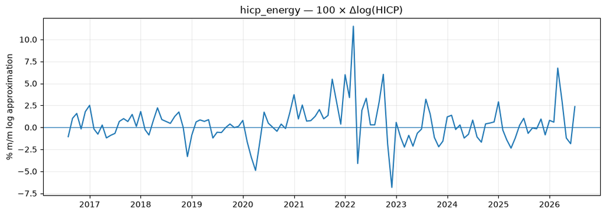

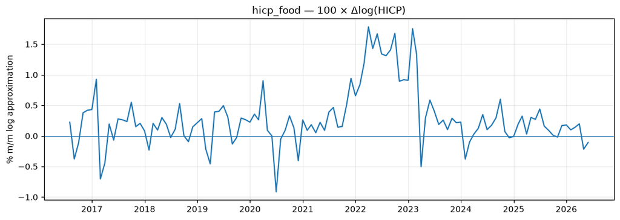

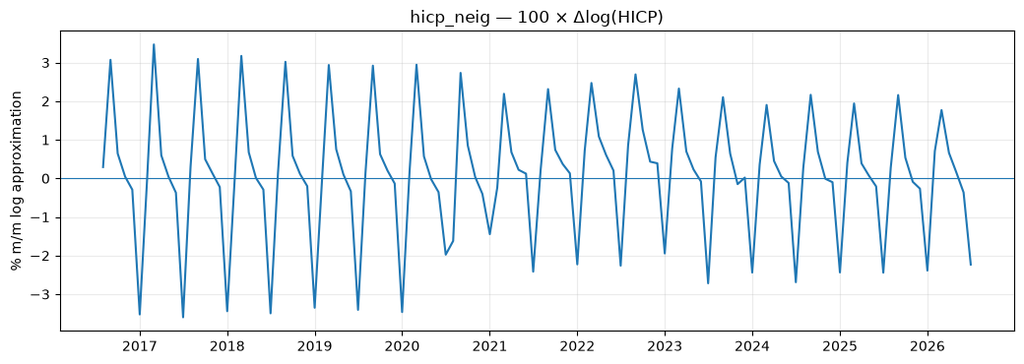

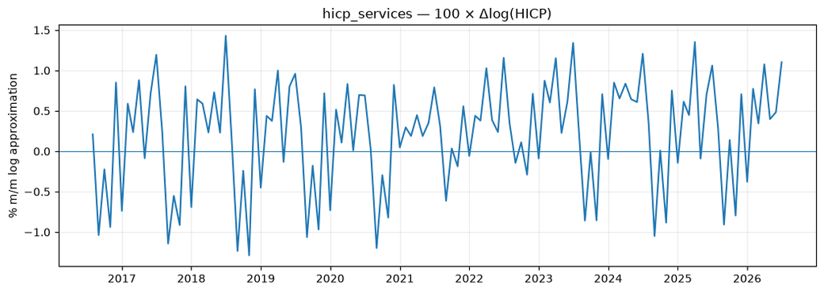

```python
state_levels = native_to_state_levels(native_levels)
model_changes = 100.0 * state_levels.diff()

display(model_changes.describe().T)

figures = plot_joint_model_changes(native_levels, last_obs=120)
for fig in figures.values():
    display(fig)
    plt.close(fig)
```

Every equation is estimated on monthly log changes:

[ 100\Delta\log(HICP_t). ]

The factor `100` above is only for human-readable plots. The shared model engine receives `log(HICP)` state levels and internally takes the ordinary first difference.